# Practical Machine Learning - Prediction Assignment

Mehran Behzad

26 6 2020

## Intro

Data from fitness tracking devices were gathered for subjects doing curls in 4 different manners (see [http://web.archive.org/web/20161224072740/http:/groupware.les.inf.puc-rio.br/har]). The goal of this assignment is to build a training model based on these data capable of predicting the tpye of exersise based of the movement data measured by these devices.

## Data exploration and cleanup

```r
# load libraries
library(dplyr)
library(caret)
# read data
training <- read.csv(file = 'data/pml-training.csv')
testing <- read.csv(file = 'data/pml-testing.csv')
```

The table has 19622 rows of data, each has 160 features.

```r
#
head(training[(1:10)])
```

```
##   X user_name raw_timestamp_part_1 raw_timestamp_part_2   cvtd_timestamp
## 1 1  carlitos           1323084231               788290 05/12/2011 11:23
## 2 2  carlitos           1323084231               808298 05/12/2011 11:23
## 3 3  carlitos           1323084231               820366 05/12/2011 11:23
## 4 4  carlitos           1323084232               120339 05/12/2011 11:23
## 5 5  carlitos           1323084232               196328 05/12/2011 11:23
## 6 6  carlitos           1323084232               304277 05/12/2011 11:23
##   new_window num_window roll_belt pitch_belt yaw_belt
## 1         no         11      1.41       8.07    -94.4
## 2         no         11      1.41       8.07    -94.4
## 3         no         11      1.42       8.07    -94.4
## 4         no         12      1.48       8.05    -94.4
## 5         no         12      1.48       8.07    -94.4
## 6         no         12      1.45       8.06    -94.4
```

It seems the first 7 columns are user specific or some time stamps and not task specific. We can remove them for the training.

```r
# remove first columns which are not relevant for the excercise
training <- training[-(1:7)]
```

Furtermore, there are alot of features that are almost N/A for all obesrvations. We will remove them:

```r
# remove column which have at least 90% NAs
training <- training[ , apply(training, 2, function(y) length(which(is.na(y))) < .90 * dim(training)[1])]
# same for test set
testing <- testing[-(1:7)]
testing <- testing[ , apply(testing, 2, function(y) length(which(is.na(y))) < .90 * dim(testing)[1])]
```

We will also remove any feature/column which is missing the Training or Testing data set which won’t help with prediction or training.

```r
# memorize the calsse column which is delibertly missing in the tetesting dataset and has to be predicted.
classe <- training$classe

# remove those which are only present in one dataset
testing <- testing[, intersect(colnames(training), colnames(testing))]
training <- training[, intersect(colnames(training), colnames(testing))]
training$classe <- classe
```

This gives us 53 features which we will feed the models with.

## Training

Now we will split our training data, to allow testing its prediction with known observations:

```r
inTrain <- createDataPartition(y= training$classe, p=0.7, list=FALSE)
trainingSub <- training[inTrain,]
testingSub <- training[-inTrain,]
```

Using the Random Forest (rf) algorithm to train the model

```r
model_rf <- train(classe  ~ ., method="rf", data = trainingSub,
               trControl = trainControl(method = "cv"),
               number = 3, na.action=na.exclude)
```

We build a second model using lda technique:

```r
model_lda <- train(classe~., method="lda", data = trainingSub,
                trControl=  trainControl(method="cv", number=10),
                na.action=na.exclude)
```

## Evaluation

```r
confusionMatrix(testingSub$classe, predict(model_rf, testingSub))
```

```
## Confusion Matrix and Statistics
##
##           Reference
## Prediction    A    B    C    D    E
##          A 1666    5    3    0    0
##          B    5 1127    6    1    0
##          C    0    2 1022    2    0
##          D    0    1   14  948    1
##          E    0    0    0    2 1080
##
## Overall Statistics
##
##                Accuracy : 0.9929
##                  95% CI : (0.9904, 0.9949)
##     No Information Rate : 0.2839
##     P-Value [Acc > NIR] : < 2.2e-16
##
##                   Kappa : 0.991
##
##  Mcnemar's Test P-Value : NA
##
## Statistics by Class:
##
##                      Class: A Class: B Class: C Class: D Class: E
## Sensitivity            0.9970   0.9930   0.9780   0.9948   0.9991
## Specificity            0.9981   0.9975   0.9992   0.9968   0.9996
## Pos Pred Value         0.9952   0.9895   0.9961   0.9834   0.9982
## Neg Pred Value         0.9988   0.9983   0.9953   0.9990   0.9998
## Prevalence             0.2839   0.1929   0.1776   0.1619   0.1837
## Detection Rate         0.2831   0.1915   0.1737   0.1611   0.1835
## Detection Prevalence   0.2845   0.1935   0.1743   0.1638   0.1839
## Balanced Accuracy      0.9976   0.9952   0.9886   0.9958   0.9993
```

```r
confusionMatrix(testingSub$classe, predict(model_lda, testingSub))
```

```
## Confusion Matrix and Statistics
##
##           Reference
## Prediction    A    B    C    D    E
##          A 1371   34  136  127    6
##          B  180  732  134   49   44
##          C  123   90  652  133   28
##          D   54   40  115  717   38
##          E   43  168  102  116  653
##
## Overall Statistics
##
##                Accuracy : 0.7009
##                  95% CI : (0.6891, 0.7126)
##     No Information Rate : 0.3009
##     P-Value [Acc > NIR] : < 2.2e-16
##
##                   Kappa : 0.6214
##
##  Mcnemar's Test P-Value : < 2.2e-16
##
## Statistics by Class:
##
##                      Class: A Class: B Class: C Class: D Class: E
## Sensitivity            0.7741   0.6880   0.5724   0.6278   0.8492
## Specificity            0.9263   0.9156   0.9212   0.9479   0.9161
## Pos Pred Value         0.8190   0.6427   0.6355   0.7438   0.6035
## Neg Pred Value         0.9050   0.9300   0.8998   0.9136   0.9758
## Prevalence             0.3009   0.1808   0.1935   0.1941   0.1307
## Detection Rate         0.2330   0.1244   0.1108   0.1218   0.1110
## Detection Prevalence   0.2845   0.1935   0.1743   0.1638   0.1839
## Balanced Accuracy      0.8502   0.8018   0.7468   0.7879   0.8827
```

It seems that the random forest method gives us a model with a hight (~99%) accuracy.

Let’s see which parameters have the mose influence:

```r
varImp(model_rf)
```

```
## rf variable importance
##
##   only 20 most important variables shown (out of 52)
##
##                      Overall
## roll_belt            100.000
## pitch_forearm         59.717
## yaw_belt              53.225
## roll_forearm          46.034
## magnet_dumbbell_z     45.959
## magnet_dumbbell_y     44.784
## pitch_belt            44.452
## accel_dumbbell_y      24.711
## accel_forearm_x       18.231
## roll_dumbbell         17.820
## magnet_dumbbell_x     16.088
## accel_belt_z          15.733
## magnet_belt_z         15.112
## magnet_forearm_z      14.639
## accel_dumbbell_z      14.250
## total_accel_dumbbell  13.488
## gyros_belt_z          12.712
## magnet_belt_y         11.953
## magnet_belt_x         11.017
## yaw_arm                9.851
```

And the one with most effect plotted:

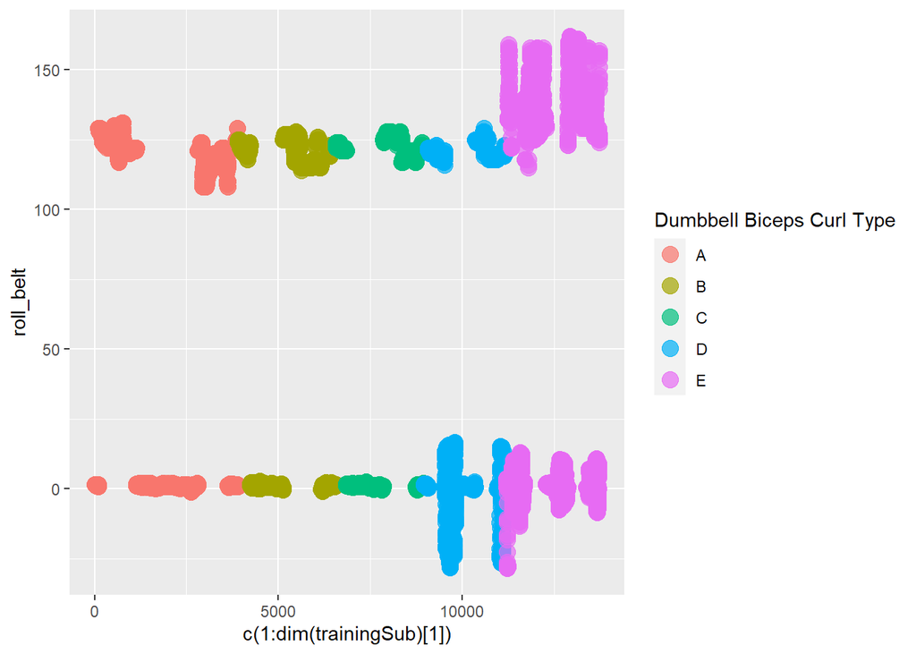

```r
ggplot(trainingSub, aes(y=roll_belt, x = c(1:dim(trainingSub)[1]), colour = factor(classe))) +
  geom_point(size=4, alpha=0.7) +
  labs(color = "Dumbbell Biceps Curl Type")
```

### Predicting testing data

```r
predict(model_rf, testing)
```

```
##  [1] B A B A A E D B A A B C B A E E A B B B
## Levels: A B C D E
```